# Annual Migration Patterns of the Canada Goose

[figure not shown]

The Canada goose (Branta canadensis) has a black head and neck, white cheeks, white under its chin, and a brown body. Even though the name suggests its origin, it is more widespread than one might think. It is native to the arctic and temperature regions of North America, but can be found in Europe, New Zealand, Japan, Chile, Argentina,and the Falkland Islands (Long, 1981).

In the chracteristic V-formation, they fly to their wintering grounds and their breeding grounds in winter, often a symbol used for the changing seasons in North America. The migration routes of the Canada goose are not genetically determined, but are passed down within the various subpopulations. Young geese learn the migration route and the location of their winter quarters during migration with their parents. Some of the most southerly subpopulations are resindet birds or partial migrants, while more northerly ones are distinct migratory. Thus, some of the more northerly populations sometimes pass their sourthern populations that remain closer to their breeding grounds and spend the winter month much further south.

Migration Data was obtained from [Global Biodiversity Information Facility (GBIF)](https://www.gbif.org). It is an international network and data infrastructure funded by the world's goverments. The Canada Goose dataset used below is for the year 2024 (GBIF.org (25 October 2025) GBIF Occurrence Download https://doi.org/10.15468/dl.hd4nsg).

## Important packages

```python
# import packages for data warngling
import pathlib
import os
import glob
import time
import pygbif.occurrences as occ
import pygbif.species as species
import getpass
import zipfile

# import packages for data analysis
import pandas as pd
import geopandas as gpd
import numpy as np

# import packages for dynamic mapping
import calendar
import cartopy.crs as ccrs
import panel as pn
import hvplot.pandas
```

## Data wrangling

The first part of this notebook deals with the collection of the necessary data and the standardization of data with regard to the coordinate system.

This included the GBIF data of the Canada goose as well as the ecoregion.

```python
# create data directory
crane_dir = os.path.join(
    ### home directory
    pathlib.Path.home(),
    ### folder with assignments for this class
    'earth-analytics',
    'data',
    # Project directory
    'migration_data')

# make the directory if it not exist already
os.makedirs(crane_dir, exist_ok = True)

# define directory for gbif data
gbif_dir = os.path.join(crane_dir, 'gbif')

# make the directory if it not exist already
os.makedirs(gbif_dir, exist_ok = True)
```

Link GBIF to your Jupyter notebook

- `reset = True` only the first time you run it. VsCode will ask for username, password and email to connect to GBIF
- `reset = False` to re-run the chunk without having to reconnect to GBIF

```python
# This code ASKS for your credentials
# and saves it for the rest of the session.
# NEVER put your credentials into your code!!!!

# GBIF needs a username, password, and email
# All 3 need to match the account
reset = False

# Request and store username
if (not ('GBIF_USER'  in os.environ)) or reset:
    os.environ['GBIF_USER'] = input('GBIF username:')

# Securely request and store password
if (not ('GBIF_PWD'  in os.environ)) or reset:
    os.environ['GBIF_PWD'] = getpass.getpass('GBIF password:')

# Request and store account email address
if (not ('GBIF_EMAIL'  in os.environ)) or reset:
    os.environ['GBIF_EMAIL'] = input('GBIF email:')
```

Get the species key for your species from GBIF using the `name_backbone` command. To get the data for the Canada goose, the latin name is used.

```python
# grab the species info
backbone = species.name_backbone(name = 'Branta canadensis')

# pull out the species key
species_key = backbone['usageKey']

# check usage keay and backbone
print('Usage Key: ', species_key)
backbone
```

```
Usage Key:  5232437
```

```
{'usageKey': 5232437,
 'scientificName': 'Branta canadensis (Linnaeus, 1758)',
 'canonicalName': 'Branta canadensis',
 'rank': 'SPECIES',
 'status': 'ACCEPTED',
 'confidence': 99,
 'matchType': 'EXACT',
 'kingdom': 'Animalia',
 'phylum': 'Chordata',
 'order': 'Anseriformes',
 'family': 'Anatidae',
 'genus': 'Branta',
 'species': 'Branta canadensis',
 'kingdomKey': 1,
 'phylumKey': 44,
 'classKey': 212,
 'orderKey': 1108,
 'familyKey': 2986,
 'genusKey': 2498190,
 'speciesKey': 5232437,
 'class': 'Aves'}
```

Download the GBIF data. It might take several minutes for the data to download. Thus, if .csv file exists in gbif directory, this code snipped will not run again. With `'*.csv'`, glob looks for all files with this ending, not for a specific file name.

```python
# Only download once
# set file name for download
gbif_pattern = os.path.join(gbif_dir, '*.csv')

# double check that there isn't already a file that matches this pattern.
# if it already exists, skip the whole conditional
# and go straight to the line: gbif_path = glob(gbif_pattern)[0]
if not glob.glob(gbif_pattern):

    # only submit a download request to GBIF once
    # if GBIF_DOWNLOAD_KEY is not defined in our environment, make the download request
    if not 'GBIF_DOWNLOAD_KEY' in os.environ:

        ### submit a query to GBIF
        gbif_query = occ.download([

            ### add your species key here
            f"speciesKey = {species_key}",

            ### filter out results that are missing coordinates
            "hasCoordinate = True",

            ### choose a year to include
            "year = 2024",
        ])
        os.environ['GBIF_DOWNLOAD_KEY'] = gbif_query[0]

    # Wait for the download to build
    download_key = os.environ['GBIF_DOWNLOAD_KEY']

    # use the occurrence command module in pygbif to get the metadata
    wait = occ.download_meta(download_key)['status']

    # check if the status of the download = "SUCCEEDED"
    # wait and loop through until it finishes
    while not wait=='SUCCEEDED':
        wait = occ.download_meta(download_key)['status']

        # don't want to re-query the API in the loop too frequently
        time.sleep(5)

    # Download GBIF data when it's ready
    download_info = occ.download_get(
        os.environ['GBIF_DOWNLOAD_KEY'],
        path=gbif_dir)

    # Unzip GBIF data using the zipfile package
    with zipfile.ZipFile(download_info['path']) as download_zip:
        download_zip.extractall(path=gbif_dir)

# Find the extracted .csv file path (take the first result)
gbif_path = glob.glob(gbif_pattern)[0]
```

The GBIF occurrence data should now be in a folder on the computer, saved as a .csv file. The file name is not meaningful. In the following, the file name is replaced if it corresponds to the old file name. This makes it clear in retrospect what is contained in the file.

```python
old_file_name = gbif_path.split('/')[-1]
new_file_name = 'Branta_canadensis_2024.csv'

try:
    os.rename(os.path.join(gbif_dir, old_file_name), os.path.join(gbif_dir, new_file_name))
    # print(f"File '{old_file_name}' renamed to '{new_file_name}'.")
    gbif_path = os.path.join(gbif_dir, new_file_name)
except OSError as e:
    print(f"Error renaming file: {e}")
```

```python
# Load the GBIF data, this time defining the delimiter (tabular) represents as '\t'
# We also set the index to gbifID, and select the columns of interest (lat, lon, and month)
gbif_df = pd.read_csv(
    gbif_path,
    delimiter='\t',
    index_col='gbifID',
    usecols=['gbifID','decimalLongitude','decimalLatitude','month']
)
gbif_df.head()
```

| gbifID | decimalLatitude | decimalLongitude | month |
| --- | --- | --- | --- |
| 4576093788 | 48.555970 | 2.396180 | 1.0 |
| 4850029298 | 64.268155 | 23.921165 | 4.0 |
| 4853590582 | 60.180281 | 24.910857 | 4.0 |
| 4846493385 | 62.072040 | 28.299090 | NaN |
| 4979010431 | 60.419173 | 22.433753 | 10.0 |

```python
# converting the DataFrame into a GeoDataFrame with geopandas
# we have to set the Coordinate Reference System.
# EPSG: 4326 is the identifier of WGS84 - World Geodetic System 1984, used in GPS
gbif_gdf = (
    gpd.GeoDataFrame(
        gbif_df,
        geometry=gpd.points_from_xy(
            gbif_df.decimalLongitude,
            gbif_df.decimalLatitude),
        crs="EPSG:4326")
    # Select the desired columns
    # excluding the latitude and longitude columns as these information
    # are in geometry
    [['month', 'geometry']]
)
gbif_gdf
```

| gbifID | month | geometry |
| --- | --- | --- |
| 4576093788 | 1.0 | POINT (2.39618 48.55597) |
| 4850029298 | 4.0 | POINT (23.92116 64.26816) |
| 4853590582 | 4.0 | POINT (24.91086 60.18028) |
| 4846493385 | NaN | POINT (28.29909 62.07204) |
| 4979010431 | 10.0 | POINT (22.43375 60.41917) |
| ... | ... | ... |
| 5827130027 | 11.0 | POINT (13.03876 47.78413) |
| 5827209841 | 3.0 | POINT (13.04096 47.7836) |
| 5758709630 | 1.0 | POINT (4.641 50.786) |
| 5758777924 | 1.0 | POINT (4.641 50.786) |
| 5758837657 | 1.0 | POINT (4.641 50.786) |

2821386 rows × 2 columns

Ecoregion information from RESOLVE:

https://www.resolve.ngo/projects/ecoregions-world

https://data-gis.unep-wcmc.org/portal/home/item.html?id=0127920779a64e3f98925f2d3da3b847

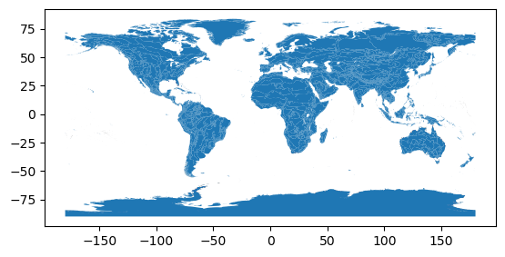

```python
# Download data
# get url for ecoregions
ecoreg_url = ("https://storage.googleapis.com/teow2016/Ecoregions2017.zip")

# set up a path to save the data on my computer
ecoreg_dir = os.path.join(crane_dir, "ecoregions")
# make the ecoregions directory
os.makedirs(ecoreg_dir, exist_ok = True)

# join ecoregions shapefile path
ecoreg_path = os.path.join(ecoreg_dir, "ecoregions.shp")

# download data once
if not os.path.exists(ecoreg_path):
    ecoreg_gdf = gpd.read_file(ecoreg_url)
    ecoreg_gdf.to_file(ecoreg_path)

# Open up the ecoregions boundaries
ecoreg_gdf = gpd.read_file(ecoreg_path)

# Plot the ecoregions quickly to check download
ecoreg_gdf.plot()
```

# Mapping migration

To map the migration to the respective ecoregion, we have to join the ecoregion GeoDataFrame and GBIF GeoDataFrame together. The new, joined, GeoDataFrame is named `gbif_ecoregion_gdf`.

```python
gbif_ecoregion_gdf = (
    ecoreg_gdf
    # Match the CRS of the GBIF data and the ecoregions
    .to_crs(gbif_gdf.crs)
    # Find ecoregion for each observation
    .sjoin(
        gbif_gdf,
        how='inner',                    # method how to join
                                        # right join should give the same result
        predicate='contains')           # specifies the spatial join

    # select required columns
    [['OBJECTID', 'ECO_NAME', 'SHAPE_AREA', 'month']]
    )
# reset index
# gbif_ecoregion_gdf.reset_index(inplace=True)
# rename former index column to ecoregion
gbif_ecoregion_gdf.rename(columns={'OBJECTID':'ecoregion',
                                    'ECO_NAME' : 'name',
                                    'SHAPE_AREA': 'area'},
                          inplace=True)
gbif_ecoregion_gdf
```

|  | ecoregion | name | area | month |
| --- | --- | --- | --- | --- |
| 2 | 3.0 | Aegean and Western Turkey sclerophyllous and m... | 13.844952 | 7.0 |
| 2 | 3.0 | Aegean and Western Turkey sclerophyllous and m... | 13.844952 | 11.0 |
| 2 | 3.0 | Aegean and Western Turkey sclerophyllous and m... | 13.844952 | 7.0 |
| 2 | 3.0 | Aegean and Western Turkey sclerophyllous and m... | 13.844952 | 7.0 |
| 4 | 5.0 | Ahklun and Kilbuck Upland Tundra | 8.196573 | 4.0 |
| ... | ... | ... | ... | ... |
| 839 | 845.0 | North Atlantic moist mixed forests | 5.586107 | 5.0 |
| 839 | 845.0 | North Atlantic moist mixed forests | 5.586107 | 5.0 |
| 839 | 845.0 | North Atlantic moist mixed forests | 5.586107 | 3.0 |
| 839 | 845.0 | North Atlantic moist mixed forests | 5.586107 | 3.0 |
| 839 | 845.0 | North Atlantic moist mixed forests | 5.586107 | 3.0 |

2718537 rows × 4 columns

Count the observations in each ecoregion and each month. In addition, keep the area (first) for every ecoregion by month.

```python
occurrence_df = (
    gbif_ecoregion_gdf
    # Select only necessary columns
    #[['ecoregion', 'month']]
    # For each ecoregion, for each month...
    .groupby(['ecoregion', 'month'])
    # ...count the number of occurrences
    .agg(occurrences=('ecoregion', 'count'),
         area=('area','first'))
)

# Get rid of rare observations (possible misidentification?)
# set to more than 3 observations for a more robust filtering.
occurrence_df = occurrence_df[occurrence_df.occurrences > 3]

# number of occurrences divided by the ecoregion area to normalize
# the occurrences by area, as the ecoregions can be quite different in size
occurrence_df['occurrences_density'] = occurrence_df.occurrences / occurrence_df.area
# drop the area column as it is not needed anymore
occurrence_df = occurrence_df.drop('area', axis=1)
occurrence_df
```

| ecoregion | month | occurrences | occurrences_density |
| --- | --- | --- | --- |
| 10.0 | 4.0 | 6 | 0.211357 |
| 11.0 | 3.0 | 13 | 1.793768 |
|  | 4.0 | 19 | 2.621661 |
|  | 5.0 | 4 | 0.551929 |
|  | 8.0 | 6 | 0.827893 |
| ... | ... | ... | ... |
| 845.0 | 8.0 | 16 | 2.864249 |
|  | 9.0 | 11 | 1.969171 |
|  | 10.0 | 10 | 1.790156 |
|  | 11.0 | 8 | 1.432124 |
|  | 12.0 | 4 | 0.716062 |

1247 rows × 2 columns

```python
# mean values for every ecoregion
mean_occurrences_by_ecoregion = (
    occurrence_df.groupby('ecoregion').mean()
)
mean_occurrences_by_ecoregion
```

| ecoregion | occurrences | occurrences_density |
| --- | --- | --- |
| 10.0 | 6.000000 | 0.211357 |
| 11.0 | 10.500000 | 1.448812 |
| 13.0 | 96.555556 | 5.635438 |
| 17.0 | 2929.833333 | 368.127290 |
| 18.0 | 4.500000 | 0.256555 |
| ... | ... | ... |
| 830.0 | 4.500000 | 0.412973 |
| 837.0 | 11.333333 | 0.145232 |
| 838.0 | 164.416667 | 38.360043 |
| 839.0 | 1468.333333 | 40.894370 |
| 845.0 | 24.583333 | 4.400799 |

128 rows × 2 columns

```python
# Take the mean by month
# mean values for every month
mean_occurrences_by_month = (
    occurrence_df.groupby('month').mean()
)
mean_occurrences_by_month
```

| month | occurrences | occurrences_density |
| --- | --- | --- |
| 1.0 | 2094.760417 | 247.113137 |
| 2.0 | 2459.578947 | 265.114825 |
| 3.0 | 3273.594059 | 309.739267 |
| 4.0 | 3842.954128 | 352.405498 |
| 5.0 | 3741.660870 | 334.729655 |
| 6.0 | 1248.690265 | 123.928931 |
| 7.0 | 1111.733333 | 118.633728 |
| 8.0 | 1223.718182 | 131.597832 |
| 9.0 | 1657.747664 | 176.476977 |
| 10.0 | 1862.320388 | 210.830385 |
| 11.0 | 1671.101010 | 182.382694 |
| 12.0 | 1878.308511 | 219.253241 |

```python
# normalize occurrences in space and time for sampling effort
# for comparison purposes, normalizing was done for occurences and
# occurrences/area, thus already normalized by area.

occurrence_df['norm_occurrences'] = (
    occurrence_df['occurrences']
    / mean_occurrences_by_ecoregion['occurrences']
    / mean_occurrences_by_month['occurrences']
)

occurrence_df['norm_occurrences_density'] = (
    occurrence_df['occurrences_density']
    / mean_occurrences_by_ecoregion['occurrences_density']
    / mean_occurrences_by_month['occurrences_density']
)
occurrence_df
```

| ecoregion | month | occurrences | occurrences_density | norm_occurrences | norm_occurrences_density |
| --- | --- | --- | --- | --- | --- |
| 10.0 | 4.0 | 6 | 0.211357 | 0.000260 | 0.002838 |
| 11.0 | 3.0 | 13 | 1.793768 | 0.000378 | 0.003997 |
|  | 4.0 | 19 | 2.621661 | 0.000471 | 0.005135 |
|  | 5.0 | 4 | 0.551929 | 0.000102 | 0.001138 |
|  | 8.0 | 6 | 0.827893 | 0.000467 | 0.004342 |
| ... | ... | ... | ... | ... | ... |
| 845.0 | 8.0 | 16 | 2.864249 | 0.000532 | 0.004946 |
|  | 9.0 | 11 | 1.969171 | 0.000270 | 0.002536 |
|  | 10.0 | 10 | 1.790156 | 0.000218 | 0.001929 |
|  | 11.0 | 8 | 1.432124 | 0.000195 | 0.001784 |
|  | 12.0 | 4 | 0.716062 | 0.000087 | 0.000742 |

1247 rows × 4 columns

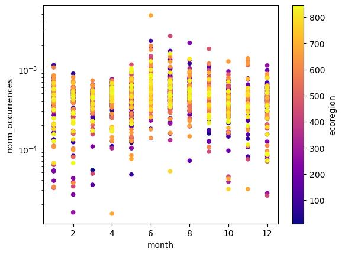

```python
# plot normalized occurrence, color-coded by ecoregion
# reset_index brings ecoregion and month in separate colmuns
occurrence_df.reset_index().plot.scatter(
    x='month',
    y='norm_occurrences',
    c='ecoregion',
    cmap='plasma',          # colormab
    logy=True               # log y-axis for better vusialization
)
```

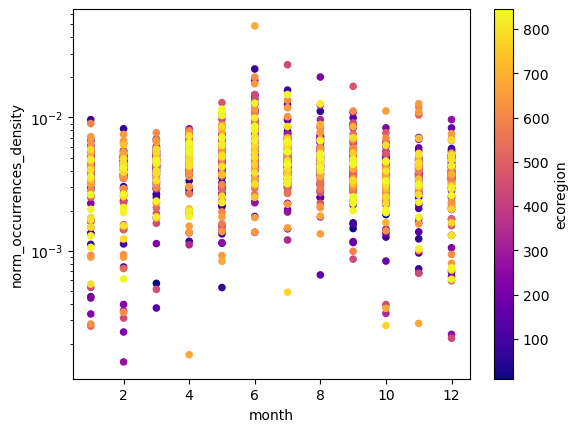

```python
# plot normalized occurrence, color-coded by ecoregion
# reset_index brings ecoregion and month in separate colmuns
occurrence_df.reset_index().plot.scatter(
    x='month',
    y='norm_occurrences_density',
    c='ecoregion',
    cmap='plasma',          # colormab
    logy=True               # log y-axis for better vusialization
)
```

## Dynamic plotting

```python
# Simplify the geometry to speed up processing
# algorythm splits the original line into smaller parts and connects these endpoints.
# removes all points whose distance to the straigt line is smaller than the tolerance.
# tolerance is .1 in  our case, preserve_topology set to False to speed up the process
ecoreg_gdf['geometry'] = ecoreg_gdf.simplify(.1, preserve_topology=False)
# Change the CRS to Mercator for mapping
ecoreg_gdf  = ecoreg_gdf.to_crs(ccrs.Mercator())
# Check that the plot runs in a reasonable amount of time
ecoreg_gdf.hvplot(geo=True, crs=ccrs.Mercator())
```

```python
# renamimg OBJECTD to ecoregion to match with occurecen_df naming
ecoreg_gdf = ecoreg_gdf.rename(columns = {'OBJECTID': 'ecoregion'})
# make ecoregion the index as in occurence_df for the next step which is the merge
ecoreg_gdf.set_index('ecoregion', inplace=True)
ecoreg_gdf
```

| ecoregion | ECO_NAME | BIOME_NUM | BIOME_NAME | REALM | ECO_BIOME_ | NNH | ECO_ID | SHAPE_LENG | SHAPE_AREA | NNH_NAME | COLOR | COLOR_BIO | COLOR_NNH | LICENSE | geometry |
| --- | --- | --- | --- | --- | --- | --- | --- | --- | --- | --- | --- | --- | --- | --- | --- |
| 1.0 | Adelie Land tundra | 11.0 | Tundra | Antarctica | AN11 | 1 | 117 | 9.749780 | 0.038948 | Half Protected | #63CFAB | #9ED7C2 | #257339 | CC-BY 4.0 | MULTIPOLYGON EMPTY |
| 2.0 | Admiralty Islands lowland rain forests | 1.0 | Tropical & Subtropical Moist Broadleaf Forests | Australasia | AU01 | 2 | 135 | 4.800349 | 0.170599 | Nature Could Reach Half Protected | #70A800 | #38A700 | #7BC141 | CC-BY 4.0 | POLYGON ((16411777.375 -229101.376, 16384825.7... |
| 3.0 | Aegean and Western Turkey sclerophyllous and m... | 12.0 | Mediterranean Forests, Woodlands & Scrub | Palearctic | PA12 | 4 | 785 | 162.523044 | 13.844952 | Nature Imperiled | #FF7F7C | #FE0000 | #EE1E23 | CC-BY 4.0 | MULTIPOLYGON (((3391149.749 4336064.109, 33846... |
| 4.0 | Afghan Mountains semi-desert | 13.0 | Deserts & Xeric Shrublands | Palearctic | PA13 | 4 | 807 | 15.084037 | 1.355536 | Nature Imperiled | #FA774D | #CC6767 | #EE1E23 | CC-BY 4.0 | MULTIPOLYGON (((7369001.698 4093509.259, 73168... |
| 5.0 | Ahklun and Kilbuck Upland Tundra | 11.0 | Tundra | Nearctic | NE11 | 1 | 404 | 22.590087 | 8.196573 | Half Protected | #4C82B6 | #9ED7C2 | #257339 | CC-BY 4.0 | MULTIPOLYGON (((-17930832.005 8046779.358, -17... |
| ... | ... | ... | ... | ... | ... | ... | ... | ... | ... | ... | ... | ... | ... | ... | ... |
| 848.0 | Sulawesi lowland rain forests | 1.0 | Tropical & Subtropical Moist Broadleaf Forests | Australasia | AU01 | 2 | 156 | 150.744361 | 9.422097 | Nature Could Reach Half Protected | #70A800 | #38A700 | #7BC141 | CC-BY 4.0 | MULTIPOLYGON (((14113374.546 501721.962, 14128... |
| 212.0 | East African montane forests | 1.0 | Tropical & Subtropical Moist Broadleaf Forests | Afrotropic | AF01 | 3 | 8 | 157.848926 | 5.010930 | Nature Could Recover | #13ED00 | #38A700 | #F9A91B | CC-BY 4.0 | MULTIPOLYGON (((4298787.669 -137583.786, 42727... |
| 224.0 | Eastern Arc forests | 1.0 | Tropical & Subtropical Moist Broadleaf Forests | Afrotropic | AF01 | 3 | 9 | 34.153333 | 0.890325 | Nature Could Recover | #267400 | #38A700 | #F9A91B | CC-BY 4.0 | MULTIPOLYGON (((4267432.68 -493759.165, 428533... |
| 79.0 | Borneo montane rain forests | 1.0 | Tropical & Subtropical Moist Broadleaf Forests | Indomalayan | IN01 | 2 | 220 | 38.280990 | 9.358407 | Nature Could Reach Half Protected | #23DB01 | #38A700 | #7BC141 | CC-BY 4.0 | MULTIPOLYGON (((13126956.393 539092.917, 13136... |
| 376.0 | Kinabalu montane alpine meadows | 10.0 | Montane Grasslands & Shrublands | Indomalayan | IN10 | 3 | 313 | 5.722539 | 0.352694 | Nature Could Recover | #C48832 | #D6C39D | #F9A91B | CC-BY 4.0 | POLYGON ((12981819.186 696445.445, 12997053.80... |

847 rows × 15 columns

```python
# Join the occurrences with the plotting GeoDataFrame
occurrence_gdf = ecoreg_gdf.join(occurrence_df)
```

```python
# getting max and min values for fixed colorbar limits
max_occurrences = occurrence_gdf['norm_occurrences_density'].max()
min_occurrences = occurrence_gdf['norm_occurrences_density'].max()

# Get the plot bounds so they don't change with the slider
xmin, ymin, xmax, ymax = occurrence_gdf.total_bounds

slider = pn.widgets.DiscreteSlider(name='month', options={calendar.month_name[i]: i for i in range(1, 13)})

# Plot occurrence by ecoregion and month
migration_plot = (
    occurrence_gdf
    .hvplot(
        c='norm_occurrences_density',
        groupby='month',
        # Use background tiles
        #cmap='Viridis',  # or any other colormap
        geo=True, crs=ccrs.Mercator(), tiles='CartoLight',
        title="Canada goose migration - 2024",
        xlim=(xmin, xmax), ylim=(ymin, ymax),
        frame_height=400,
        frame_width=600,
        widget_location='bottom',
        #cmap='viridis',
        #colorbar = True,
        clim=(0.00013, 0.048),
        widgets = {'month': slider}
    )
)


# Save the plot
migration_plot.save('canada_goose.html',
                    embed=True,
                    )
# display plot
migration_plot
```

```
WARNING:W-1005 (FIXED_SIZING_MODE): 'fixed' sizing mode requires width and height to be set: figure(id='p11482', ...)
```

```
BokehModel(combine_events=True, render_bundle={'docs_json': {'d03ca64f-d505-4a59-82ca-4e67059abb51': {'version…
```

## Migration patterns of the Canada goose - differences between continents

This brief analysis of the migration of the Canada goose is based on the GBIF database from 2024. The occurrences of this year were linked to maps of the ecoregions and then grouped by ecoregion and month. Very rare occurrences (three and less) were excluded of the anaylsis. In addition, the grouped occurrences were normalized to the size of the ecoregions. Furthermore, the occurrences were normalized in space and time. Finally, the normalized occurrences per ecoregion by month of the year are plotted.

It can be seen that, based on the GBIF database, the occurrences are mainly limited to North America, Europe, and New Zealand. This agrees with the literature, which identifies these as the main areas of occurrence (e.g. [Canada Goose Facts](https://www.thoughtco.com/canada-goose-bird-facts-4584329)). The Canada goose was introduced to England as early as the 17th century. In the 19th century, the Canada goose was also recorded as ornamental poultry on the European mainland. In New Zealand, however, the Canada goose was introduced not as ornamental poultry but as game for hunting.

I would like to highlight a few special features that stood out in the graphic representation of the migration:

- In North America and Europe, there is a noticeable migration toward higher northern latitudes during the summer months. However, a certain number always remain in southern latitudes. This reflects the mixture of different subspecies and their migration patterns. Some of the most southerly subpopulations are resindet birds or partial migrants, while more northerly ones are distinct migratory which migrates to warmer regions in the south during winter.
- The occurrences in New Zealand are relatively consistent throughout the year, indicating that there is little migration there. Migration here occurs more from the South Island to the North Island and vice versa.
- Particularly in June, a considerably higher occurrence can be observed in the southern part of Hudson Bay and James Bay. A very recent publication by [Sorais et al. (2023)](https://nsojournals.onlinelibrary.wiley.com/doi/full/10.1002/wlb3.01062) described movement patterns and habitat use of molt migrant Canada geese along the east coast of James Bay. They report that the number of Canada geese breeding in temperate zones along the Atlantic and Mississippi flyways has increased significantly since the 1980s. Geese spent 2.8 ± 0.6 days (mean ± standard error of the mean) at 3.2 ± 0.6 resting places (mainly mudflats and salt marshes) from the first week of June in spring and 3.8 ± 1.8 days at 2.0 ± 0.5 resting places (mainly inland waters, moors, and mudflats) from the first week of September on their return south. The increased occurrence in June in particular coincides with the GBIF occurrences.

A detailed analysis of the migration behavior of Canada geese would be very interesting. To this end, it would be useful to have longer records covering several years in order to identify changes in migration patterns caused by factors such as climate change and hunting behavior, e.g. populatioin change due to more hunting of Canada geese.

### Bibliography

Long, John L.: Introduced Birds of the World. Agricultural Protection Board of Western Australia. pp. 21–493. (1981).

Sorais, M., Patenaude-Monette, M., Sharp, C., Askren, R., LaRocque, A., Leblon, B. and Giroux, J.-F.: Migration patterns and habitat use by molt migrant temperate-breeding Canada geese in James Bay, Canada. Wildlife Biology, (2023): e01062. https://doi.org/10.1002/wlb3.01062

GBIF.org (25 October 2025) GBIF Occurrence Download https://doi.org/10.15468/dl.hd4nsg